# Creating data-driven terrain meshes from spatial points of interest

*Mike Mahoney* • *Last updated: August 26 2020*

## Problem Statement

Interactive landscape visualizations require realistic terrain rendering in order to properly represent the place being simulated. Researchers and designers have historically manually produced these terrains, either interactively painting surfaces or using user interfaces to produce individual terrain spans from geospatial data. However, it is not currently possible to generate a realistic terrain mesh programmatically, as would be required to automatically generate landscape simulations from geospatial data points. As such, this project aims to create a pipeline to automatically create terrain meshes from geospatial data with minimal user input, which can then be either moved into a rendering engine for manual editing or included in a larger pipeline to produce fully-fledged landscape simulations.

## High-level overview

[interactive chart not shown]

Fig 1: A theoretical flow diagram of a pipeline to create digital terrain meshes from either a set of desired points or a bounding box. Dashed cells represent optional steps. Circular cells represent external data, rectangles processes to be developed in the process of this project.

## Pipeline Walkthrough

The rest of this document discusses each of the steps of the above pipeline and provides R code when possible to process each step in turn.

There are two proposed entry points into this pipeline. In the first scenario, the pipeline is provided with a list of point features, in tabular format, representing points of interest for the simulation.

```r
simulated_data <-  data.frame(id = seq(1, 100, 1),
                              lat = runif(100, 44.04905, 44.17609),
                              lng = runif(100, -74.01188, -73.83493))
head(simulated_data)
```

```
##   id      lat       lng
## 1  1 44.05840 -73.87787
## 2  2 44.14018 -73.88248
## 3  3 44.15733 -73.86789
## 4  4 44.12206 -73.90899
## 5  5 44.16898 -73.84121
## 6  6 44.15689 -73.93141
```

From those points, we will then extract a bounding box containing those points, representing the area we will produce a terrain mesh for.

```r
simulated_bounding_box <- list(
  bl = c(lat = min(simulated_data$lat),
         lng = min(simulated_data$lng)),
  tr = c(lat = max(simulated_data$lat),
         lng = max(simulated_data$lng))
)

simulated_bounding_box
```

```
## $bl
##       lat       lng
##  44.04980 -74.01143
##
## $tr
##       lat       lng
##  44.17596 -73.83630
```

The alternative entry point is that the user, rather than providing a list of points of interest, provides a bounding box representing their area of interest. While we would not need to calculate a bounding box for this entry point, the rest of the pipeline functions identically.

For both entry points, we would then provide the user with an option to add a buffer (of user-specified size) around their bounding box, so that the resulting mesh doesn’t simply end at the edge of the area of interest.

```r
# TODO: code to add buffer to bounding box
buffered_bounding_box <- simulated_bounding_box
```

With our finalized bounding box in place, we are now able to retrieve data from the USGS 3D Elevation Program service. While other elevation models provide higher resolution terrain measurements, the DEM provides a national-level data set with an accessible REST API with continually improving granularity which will interpolate values into a specified number of pixels, without needing us to persist data for users or develop an additional service.

Below is sample code for retrieving a heightmap for our example data. Note that this code retrieves a surface 600 pixels by 600 pixels across; this is due in part to computational limitations (the USGS service will not return more than 8000 pixels in either direction in one query, and processing a matrix that large in R can be quite difficult) and part so this illustration executes faster.

```r
heightmap_retriever <- function (bbox, img.width = 600, img.height = 600, verbose = FALSE)
{

  first_corner <- c(lat = bbox[[1]][["lat"]], lng = bbox[[1]][["lng"]])
  second_corner <- c(lat = bbox[[2]][["lat"]], lng = bbox[[2]][["lng"]])

  # API endpoint for elevation mapping:
  url <- httr::parse_url("https://elevation.nationalmap.gov/arcgis/rest/services/3DEPElevation/ImageServer/exportImage")

  counter <- 0
  get_tif <- function() {
    res <- httr::GET(url,
                     query = list(bbox = paste(min(first_corner[["lng"]],
                                                   second_corner[["lng"]]),
                                               min(first_corner[["lat"]],
                                                   second_corner[["lat"]]),
                                               max(second_corner[["lng"]],
                                                   first_corner[["lng"]]),
                                               max(second_corner[["lat"]],
                                                   first_corner[["lat"]]),
                                               sep = ","),
                                  bboxSR = 4326,
                                  imageSR = 4326,
                                  size = paste(img.width, img.height, sep = ","),
                                  format = "tiff",
                                  pixelType = "F32",
                                  noDataInterpretation = "esriNoDataMatchAny",
                                  interpolation = "+RSP_BilinearInterpolation",
                                  f = "json"))

    body <- httr::content(res, type = "application/json")
    Sys.sleep(1)
    img_res <- httr::GET(body$href)
  }

    img_res <- get_tif()

    counter <- 1
    while (httr::status_code(img_res) != 200 && counter < 15) {
        img_res <- get_tif()
        if (verbose) {
            print(paste0("Attempt #", counter, ": status code ",
                httr::status_code(img_res)))
        }
        counter <- counter + 1
    }
    if (httr::status_code(img_res) != 200) {
        stop(paste("Map server returned error code", httr::status_code(img_res)))
    }

    img_bin <- httr::content(img_res, "raw")
    tif.filename <- tempfile("download", tempdir(), ".tiff")
    writeBin(img_bin, tif.filename)
    raster_read <- raster::raster(tif.filename)

    # note the raster is transposed here for compatibility with
    invisible(matrix(raster::extract(raster_read, raster::extent(raster_read),
        buffer = 1000), nrow = ncol(raster_read), ncol = nrow(raster_read)))
}

simulated_heightmap <- heightmap_retriever(buffered_bounding_box)

dim(simulated_heightmap)
```

```
## [1] 600 600
```

As a slight digression, we will likely need to decide upon a standard pixel resolution. The workflow to retrieve the heightmap will likely require us to determine the length of each axis of our mesh, convert that into our standard pixel unit, split the retrieval of DEM data into tiles, and then combine the tiles at the end; I have not written code capable of handling this increase in complexity yet.

We now have a matrix with the specified width and height. The next step is to use this raster to produce a terrain mesh. One possible approach is to export the raster to a system file and make use of GDAL to [convert our raster into contours](https://gdal.org/programs/gdal_contour.html), then utilize RHINO to convert those contours into a mesh. A second approach is to instead convert the raster into an ASCII grid (using `gdal_translate`), which we then would use RHINO to convert into a mesh. It might also be possible to produce a terrain mesh ourselves (via GDAL) without incorporating RHINO; this would likely be a more involved process than leveraging RHINO, but would allow the work to be fully portable across computers and to utilize only free software.

A final target step would involve generating realistic groundcover for the terrain mesh, preventing the user from needing to paint the cover in a rendering engine. As there is not a publicly-available database of groundcover images in the same way as we’re able to obtain satellite images and elevation data, we will at most be able to produce a reasonable fascimile of what groundcover at a given site might look like.

For the sake of completeness, I want to note that the ability to transform these elevation maps into terrain meshes already exists to a certain extent in R via the `rayshader` package. While the resulting hillshades are not extant physics objects, it is possible that – if we aren’t able to generate functional meshes in our desired formats via GDAL – we could borrow and extend work done in this package.

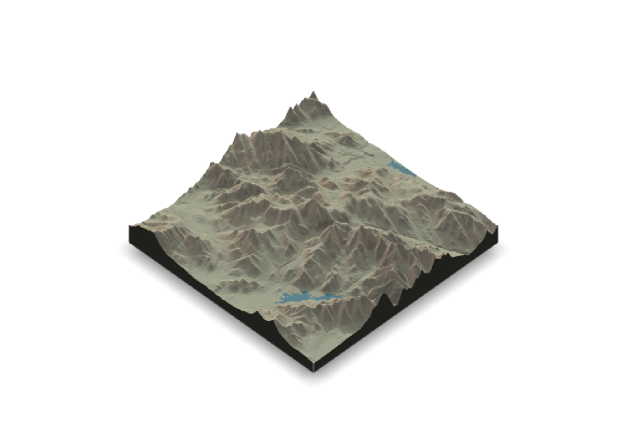

```r
library(magrittr)
library(rayshader)
shaded_map <- simulated_heightmap %>%
  rayshader::sphere_shade(zscale = 9, texture = "imhof4") %>%
  rayshader::add_water(rayshader::detect_water(simulated_heightmap, zscale = 9),
                       color = "imhof4") %>%
  rayshader::add_shadow(rayshader::ray_shade(simulated_heightmap, zscale = 9),
                        max_darken = 0.5) %>%
  rayshader::add_shadow(rayshader::ambient_shade(simulated_heightmap, zscale = 9),
                        max_darken = 0.5)


plot_3d(shaded_map, simulated_heightmap, 9)
Sys.sleep(1)
rayshader::render_snapshot()
```